# Compilation of Projects: profile of Hungary

by JUMEX365 et al

## Loading packages

First, we load all the necessary packages for the project

```r
library(foreign)
library(dplyr)
library(readr)
library(psych)
library(ggplot2)
library(knitr)
library(sjPlot)
library(corrplot)
library(lsr)
library(car)
library(broom)
library(rstatix)
library(jtools)
library(lm.beta)
library(margins)
```

## Loading data

```r
Hungary <- read.spss ("ESS9HU.sav", use.value.label=T, to.data.frame=T)
```

# Project 1: Descriptive statistics on socio-demographic profile of Hungary

## Research question

We are specially interested in correlations and patterns among marital status and educational years and place of residence of Hungarians. We also interested in a further consequences of such patterns.

Thus, our research question is the following: *Does the education and place of residence influence on marital age?*

### Subset with all necessary variables

```r
hu <- Hungary [c("gndr", "agea", "yrbrn", "maryr", "marsts", "domicil", "eduyrs")]
```

Let’s check whether everything is fine.

```r
head(hu)
```

```
##     gndr agea yrbrn maryr
## 1 Female   37  1982  2016
## 2 Female   70  1949  1970
## 3 Female   67  1952  1982
## 4   Male   38  1981  <NA>
## 5   Male   30  1989  <NA>
## 6   Male   51  1968  1992
##                                                               marsts
## 1                                                               <NA>
## 2                                                               <NA>
## 3                                         Widowed/Civil partner died
## 4                                                               <NA>
## 5 None of these (NEVER married or in legally registered civil union)
## 6                                                               <NA>
##              domicil eduyrs
## 1 Town or small city     12
## 2    Country village      8
## 3         A big city     17
## 4    Country village     11
## 5 Town or small city     14
## 6 Town or small city     11
```

## Variables

Now let’s proceed to the determination of variables.

```r
str(hu)
```

```
## 'data.frame':    1661 obs. of  7 variables:
##  $ gndr   : Factor w/ 2 levels "Male","Female": 2 2 2 1 1 1 1 1 2 2 ...
##  $ agea   : Factor w/ 75 levels "16","17","18",..: 22 55 52 23 15 36 45 36 46 4 ...
##  $ yrbrn  : Factor w/ 75 levels "1929","1930",..: 54 21 24 53 61 40 31 40 30 72 ...
##  $ maryr  : Factor w/ 71 levels "1946","1948",..: 69 23 35 NA NA 45 43 NA 32 NA ...
##  $ marsts : Factor w/ 6 levels "Legally married",..: NA NA 5 NA 6 NA NA 6 NA NA ...
##  $ domicil: Factor w/ 5 levels "A big city","Suburbs or outskirts of big city",..: 3 4 1 4 3 3 4 4 3 4 ...
##  $ eduyrs : Factor w/ 27 levels "1","3","4","5",..: 11 7 16 10 13 10 17 11 22 11 ...
```

As we may see, not all these variables are categorical, so we should define them manually and change the type if it is necessary. We also should remind, that ratio and internal variables are both named as *numeric*.

`gndr` - nominal, is *gender* basically `domicil` - nominal, *Birthplace* (Village, Small town, Big city…) `marsts` - nominal, is the *marital status of a person* (Civil Marriage, Divorced…) `yrbrn` - interval, is the *Year of birth*, where is **no absolute zero** `agea` - ratio, is the *age of respondents*. Here there is an **absolute zero**. Thus, we consider this variable as ratio -> *numeric* in R `maryr` - interval, *Year of the first marriage* ( again there is **no absolute zero**) `eduyrs` - interval, *Years of education* is an interval variable (**no absolute zero**)

Changing type!

```r
hu$yrbrn <- as.numeric(as.character(hu$yrbrn))
hu$agea <- as.numeric(as.character(hu$agea))
hu$maryr <- as.numeric(as.character(hu$maryr))
hu$eduyrs <- as.numeric(as.character(hu$eduyrs))
```

All other variables are nominal or ordinal, thus, we saved the default type that is *factor*

Thus, let’s check variables type again!

```r
str(hu)
```

```
## 'data.frame':    1661 obs. of  7 variables:
##  $ gndr   : Factor w/ 2 levels "Male","Female": 2 2 2 1 1 1 1 1 2 2 ...
##  $ agea   : num  37 70 67 38 30 51 60 51 61 19 ...
##  $ yrbrn  : num  1982 1949 1952 1981 1989 ...
##  $ maryr  : num  2016 1970 1982 NA NA ...
##  $ marsts : Factor w/ 6 levels "Legally married",..: NA NA 5 NA 6 NA NA 6 NA NA ...
##  $ domicil: Factor w/ 5 levels "A big city","Suburbs or outskirts of big city",..: 3 4 1 4 3 3 4 4 3 4 ...
##  $ eduyrs : num  12 8 17 11 14 11 18 12 23 12 ...
```

Before creating plots, we have to create a variable that will illustrate people’s marital age, that we will use in in the following graphs.

```r
hu$mrage <- (hu$maryr - hu$yrbrn)
```

Let’s check class of new data now.

```r
class(hu$mrage)
```

```
## [1] "numeric"
```

All is great, so we may proceed to the *descriptive statistics*.

## Descriptive Statistics

```r
describe(hu)
```

```
##          vars    n    mean    sd median trimmed   mad  min  max range  skew
## gndr*       1 1661    1.57  0.49      2    1.59  0.00    1    2     1 -0.30
## agea        2 1661   50.97 18.48     51   51.05 22.24   16   90    74 -0.03
## yrbrn       3 1661 1968.03 18.48   1968 1967.95 22.24 1929 2003    74  0.03
## maryr       4 1117 1984.06 16.58   1983 1983.75 19.27 1946 2018    72  0.16
## marsts*     5  898    5.18  1.10      6    5.35  0.00    1    6     5 -1.86
## domicil*    6 1660    2.91  1.12      3    3.01  1.48    1    5     4 -0.71
## eduyrs      7 1649   12.29  3.38     12   12.12  2.97    1   39    38  0.83
## mrage       8 1117   23.46  4.42     23   23.00  4.45   12   50    38  1.39
##          kurtosis   se
## gndr*       -1.91 0.01
## agea        -0.98 0.45
## yrbrn       -0.98 0.45
## maryr       -0.88 0.50
## marsts*      4.37 0.04
## domicil*    -0.85 0.03
## eduyrs       3.89 0.08
## mrage        3.51 0.13
```

```r
hu_st <- describe(hu)
```

This gives us a complete picture of how things are on average. But there is still lack of some information.

Creating function for defining **mode** (note,that it is exclude NA values)

```r
function.mode <- function(x) {
  theonly <- na.omit(unique(x))
  theonly[which.max(tabulate(match(x, theonly,  nomatch = NA_integer_, incomparables = NULL)))]
}
```

**mode values**

```r
function.mode(hu$agea)
```

```
## [1] 43
```

```r
function.mode(hu$yrbrn)
```

```
## [1] 1976
```

```r
function.mode(hu$maryr)
```

```
## [1] 1970
```

```r
function.mode(hu$eduyrs)
```

```
## [1] 12
```

```r
function.mode(hu$mrage)
```

```
## [1] 21
```

```r
function.mode(hu$gndr)
```

```
## [1] Female
## Levels: Male Female
```

```r
function.mode(hu$domicil)
```

```
## [1] Country village
## 5 Levels: A big city Suburbs or outskirts of big city ... Farm or home in countryside
```

```r
function.mode(hu$marsts)
```

```
## [1] None of these (NEVER married or in legally registered civil union)
## 6 Levels: Legally married ... None of these (NEVER married or in legally registered civil union)
```

Final table with mode.

```r
hu_mode <- hu_st
vec <- c(43, 1976, 1970, 12, 21, "Female", "Country village", "None of these")
hu_mode$mode <- vec

kable(hu_mode)
```

[output not shown]

## Graphs and visualization

### *Histogram* of a univariate distribution

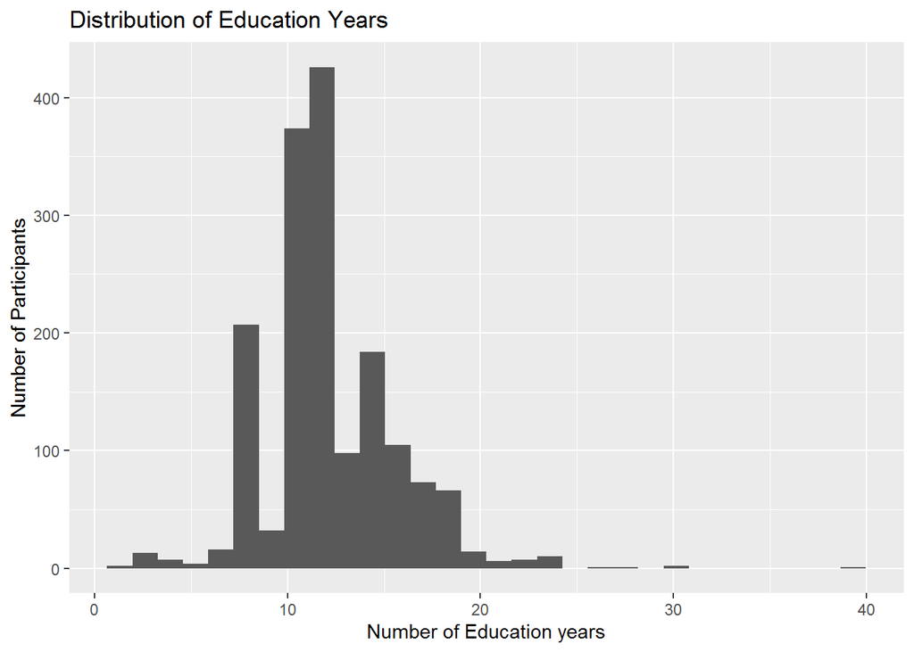

```r
ggplot(hu) + geom_histogram(aes(x=eduyrs)) +
  xlab("Number of Education years") +
  ylab("Number of Participants") +
  ggtitle("Distribution of Education Years")
```

### *Barplot* of a univariate distribution

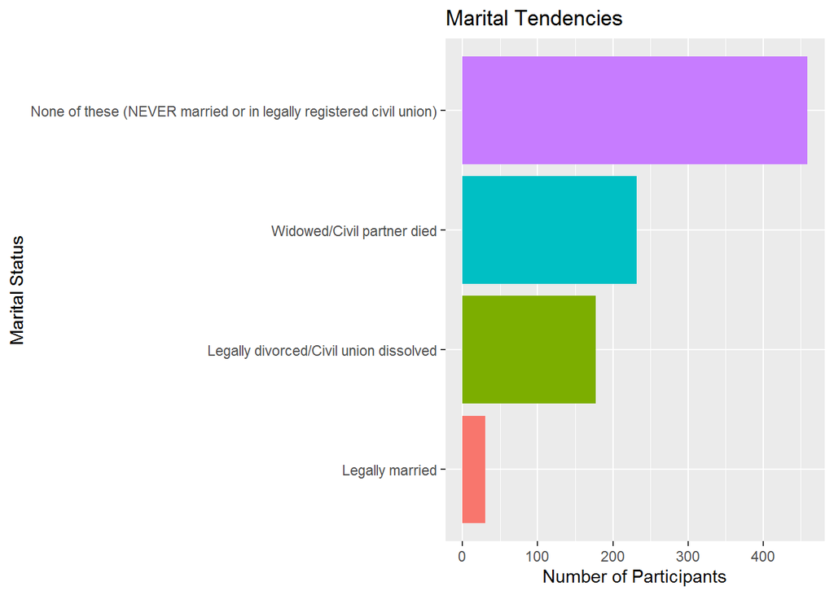

```r
hu1 <- filter(hu, hu$marsts != "NA")
ggplot(hu1) +
  geom_bar(mapping = aes(marsts, fill=marsts), show.legend = FALSE) +
  coord_flip() +
  xlab("Marital Status") +
  ylab("Number of Participants") +
  ggtitle("Marital Tendencies")
```

Second graph represents the marital status distribution among Hungarian citizens. Here we see that the majority of sample (that is about 470) in the country have never been married. Moreover, many participants (approximately ~400) in country are widowed or divorced, and only the smallest part (less than 50) stay in the legal marriage.

### *Scatterplot* of a bivariate distribution

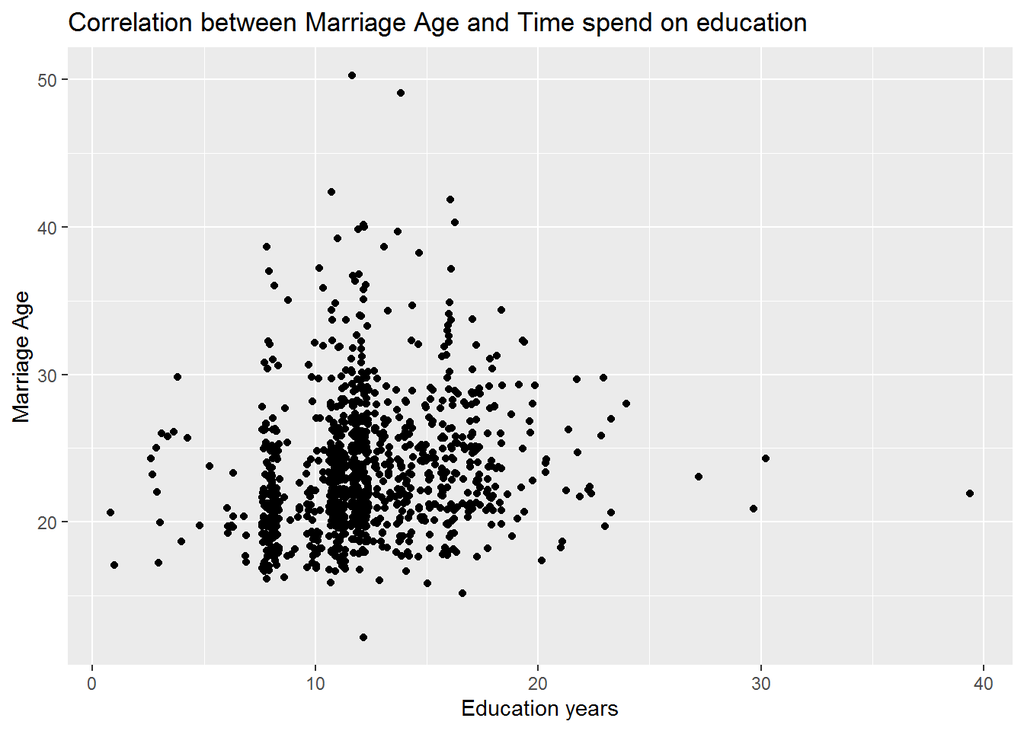

```r
mar <- hu [c("mrage", "eduyrs")]
mar1 <- na.omit(mar)
ggplot(mar1) +
  geom_point(aes(x = eduyrs, y = mrage), position = "jitter") +
  xlab("Education years") +
  ylab("Marriage Age") +
  ggtitle("Correlation between Marriage Age and Time spend on education")
```

### *Boxplot* of a bivariate distribution

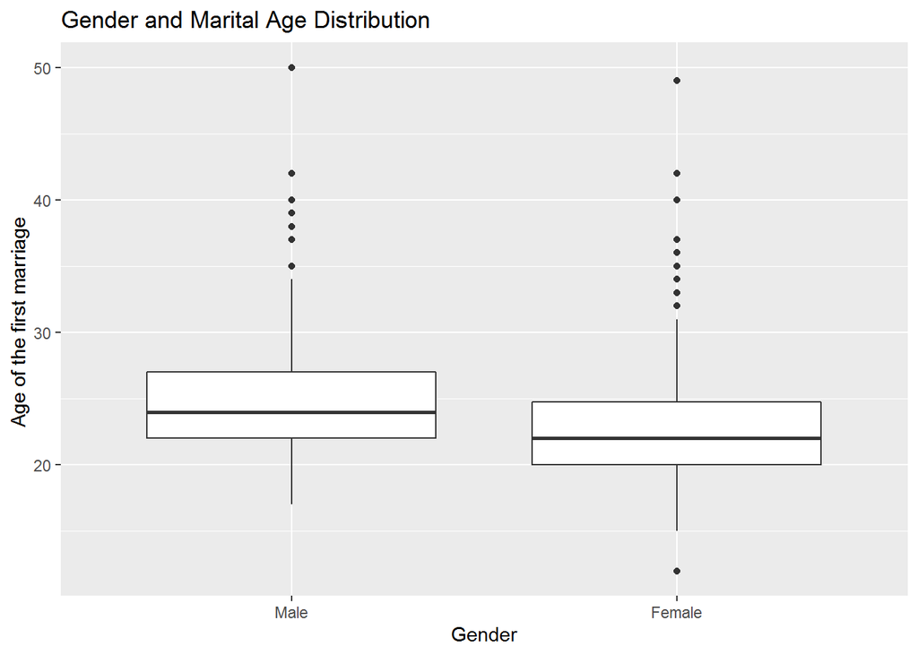

```r
ggplot(hu) +
  geom_boxplot(aes(x=gndr, y=mrage)) +
  xlab("Gender") +
  ylab("Age of the first marriage ") +
  ggtitle("Gender and Marital Age Distribution")
```

The boxplot shows the distribution of marital age among men and women. Here we may observe that males tend to get married later than females. Thus, on average men are older than women in the first marriage. Thus, as the mean value is 23, it is more related to the man, as woman’s age is closer to 21. The sizes of boxes are pretty equal, however, we may see that among females there is more outliers (as those who married earlier than in 20, and those who later).

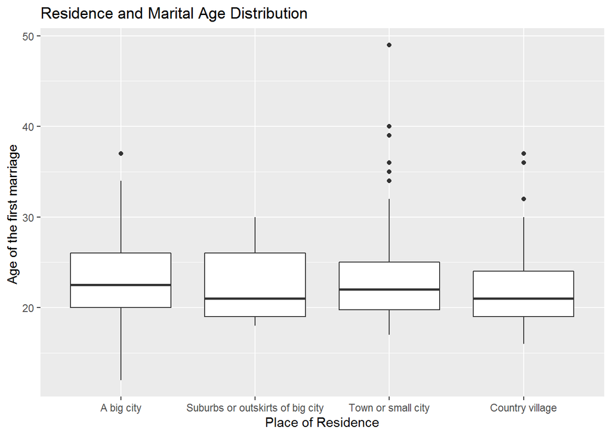

```r
hu2 <- filter(hu, hu$domicil != "NA", hu$domicil != "Farm or home in countryside", hu$marsts != "NA")

ggplot(hu2) +
  geom_boxplot(aes(x=domicil, y=mrage)) +
  xlab("Place of Residence") +
  ylab("Age of the first marriage ") +
  ggtitle("Residence and Marital Age Distribution")
```

At these boxplots we may observe some patterns, like the older marriage age of big city inhabitants. it is also interesting, that in smaller towns there are much more outliers. The case of suburbs looks like the middle between village and a big city. It is skewed to the higher age, however it arranges wider. So, we may say, that the more close to the mean age of 23 are people who live in a big city or a town. Population of a smaller residences tends to marry earlier (~ 21).

### *Stacked barplot* of a bivariate distribution

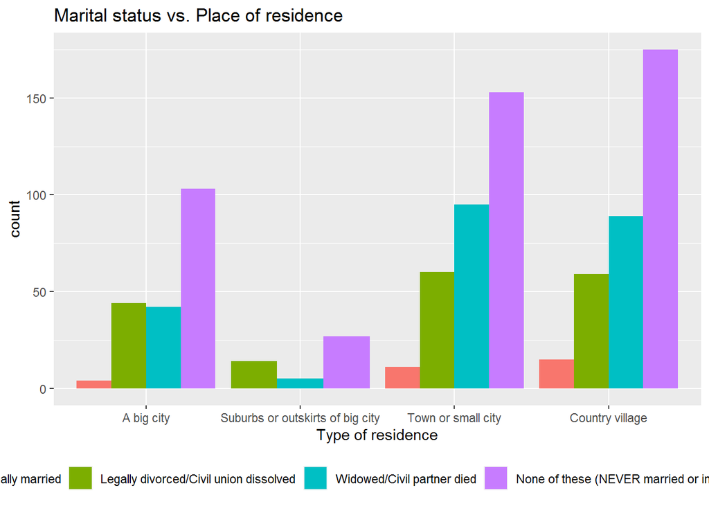

```r
ggplot(hu2) +
  geom_bar(aes(x = domicil, fill = marsts), position = "dodge") +
  ggtitle("Marital status vs. Place of residence") +
  theme(legend.position = "bottom") +
  xlab("Type of residence") +
  labs(fill = "marsts")
```

# Project 2: Basic Tests

## Research area

As it was in our previous project, we conducted a small study on socio-demographic characteristics of Hungary population.

## Chi-squared Test

First, we start with data export and its updating for *Chi-squared Test*

```r
Hungary_chi <- Hungary [c("gndr", "emplrel")]
```

For Chi-squared test two categorical variables are needed. In our case these are: `gndr` (gender of a person) - nominal, `emplrel` (employment form -> whether the person is an employee/self-employed/working for own family buisness) - nominal

Their values are specified below: Gender of a person:

```r
table(Hungary_chi$gndr)
```

```
##
##   Male Female
##    706    955
```

Employment form

```r
table(Hungary_chi$emplrel)
```

```
##
##                        Employee                   Self-employed
##                            1396                              92
## Working for own family business
##                              29
```

Next, we *specify the hypotheses*: H0 = For the population of Hungarian citizens, *gender of a person and his/her employment form are independent*. H1 = For the population of Hungarian citizens, *gender of a person and his/her employment form are dependent*

We also formulate a *substantive hypothesis*: we expect to see the association between gender of a person and his/her employment form (whether a person is an employee, self-employed or working for family business). In particular, we expect to see more self-employed people among the group of males and more generally employed among the females.

When the variables are defined and hypotheses are spelled out, we *construct a Stacked bar plot*

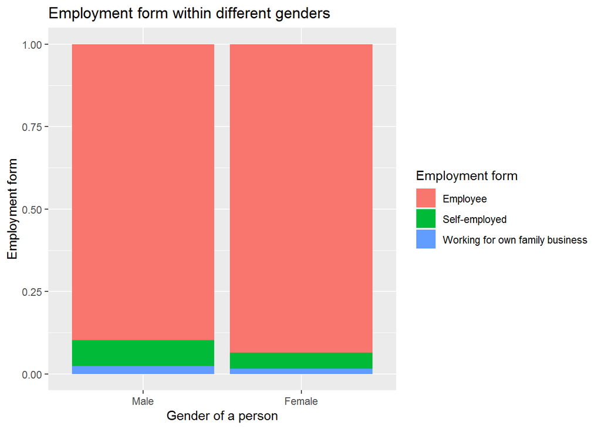

```r
Hungary_chi_1 <- filter(Hungary_chi, Hungary_chi$emplrel != "NA")
ggplot(Hungary_chi_1) +
  geom_bar(aes(x = gndr, fill = emplrel), position="fill") +
  ggtitle("Employment form within different genders") +
  xlab("Gender of a person") +
  ylab("Employment form") +
  labs(fill = "Employment form")
```

With the help of visualization, we can interpret the results: On the graph we see that within both genders being an employee is the dominant form of employment. However, even though the difference is not crucial, among males the self-employment is more popular than among females.

Now we can move to the test to check the hypotheses. However, before running the real chi-squared test, we *check the assumptions* that should be met:

- Each observation in the data contribute exclusively to one group -> observations are independent

```r
table(Hungary_chi_1)
```

```
##         emplrel
## gndr     Employee Self-employed Working for own family business
##   Male        574            50                              15
##   Female      822            42                              14
```

We check whether the data contains no expected counts less than 1, so we look at the expected frequencies. Here we also check if there are >5 observations per each sell:

```r
Hungary_chi_2 <- table(Hungary_chi_1)
chisq.test(Hungary_chi_2)$exp
```

```
##         emplrel
## gndr     Employee Self-employed Working for own family business
##   Male   588.0316       38.7528                        12.21556
##   Female 807.9684       53.2472                        16.78444
```

Now, when we checked our data, **we can run the test**:

```r
chisq.test(Hungary_chi_2)
```

```
##
##  Pearson's Chi-squared test
##
## data:  Hungary_chi_2
## X-squared = 7.3151, df = 2, p-value = 0.0258
```

We see that the p-value equals 0,0258 (p<0,05) -> *the test is significant*, so there is an association between the gender of a person and his/her employment form. We *reject the null hypothesis*. However, to inspect these differences in more details we need to look at the residuals:

```r
chires <- chisq.test(Hungary_chi_2)
chires$stdres
```

```
##         emplrel
## gndr      Employee Self-employed Working for own family business
##   Male   -2.693108      2.450325                        1.057349
##   Female  2.693108     -2.450325                       -1.057349
```

We see that some values of the residuals lie outside of +-1,96, so they are significant (with p-value<0,5). These are: male employees, self-employed males, female employees, self-employed females. Thus, the forms of self-employment and being an employee have an **association** with the gender of a person. While working for own family business do not give us proper information for making conclusions.

We can also visualize the residuals for easier interpretation:

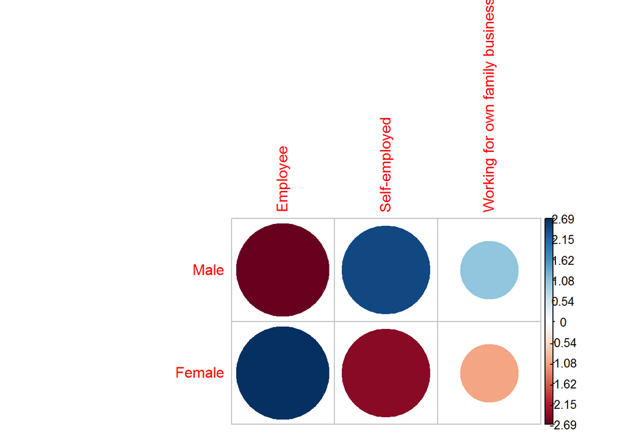

```r
corrplot(chires$stdres, is.cor = FALSE)
```

The visualization allows us to see the positive association between the self-employment and male gender, as well as between female gender and working as an employee.

Overall, gender of a person and employment form do correlate. Males are more likely to be self-employed than females, while females prefer the general employment. Thus, with the help of chi-squared test, *we have rejected the null-hypothesis* and proved that the **variables are dependent**

## T-test

Select columns, that can be used in T-test

```r
Hu_v1.0 <- Hungary [c("iagmr", "iagpnt")]
Hu_v1.0 <- na.omit(Hu_v1.0)
Hu_v2.0 <- Hu_v1.0[Hu_v1.0$iagmr != "No ideal age" & Hu_v1.0$iagmr != "Should never get married" & Hu_v1.0$iagpnt != "No ideal age", ]
```

Deleting open-ended answers (and left only numeric) to use statistical methods in future.

Renaming columns for better layout

```r
Hu_v3.0 <- Hu_v2.0 %>%
  rename(ideal_marriage_age=iagmr, ideal_parenthood_age=iagpnt)
```

The data format may look a little strange, but we assume that for all numbers from the first column the factor is `ideal_marriage_age`, and for the second - factor is `ideal_parenthood_age`.

Working on a data type

```r
class(Hu_v3.0$ideal_marriage_age)
```

```
## [1] "factor"
```

```r
class(Hu_v3.0$ideal_parenthood_age)
```

```
## [1] "factor"
```

Data type - factor. Need to change it.

Changing data type to numeric.

```r
Hu_v3.0$ideal_marriage_age <- as.numeric(as.character(Hu_v3.0$ideal_marriage_age))
Hu_v3.0$ideal_parenthood_age <- as.numeric(as.character(Hu_v3.0$ideal_parenthood_age))
```

Re-check

```r
class(Hu_v3.0$ideal_marriage_age)
```

```
## [1] "numeric"
```

```r
class(Hu_v3.0$ideal_parenthood_age)
```

```
## [1] "numeric"
```

Everything is fine.

Creating a *boxplot*

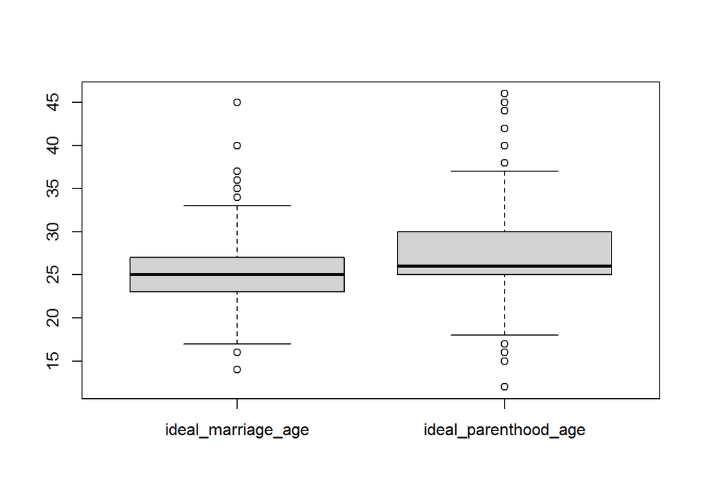

```r
boxplot(Hu_v3.0)
```

**State the hypothesis**. Null hypothesis: the mean values of ideal_marriage_age and ideal_parenthood_age are equal. Alternative hypothesis: the mean values of ideal_marriage_age and ideal_parenthood_age not equal. If during the t.test p will be < 0.05, we will reject the null hypothesis. If during the t.test p will be > 0.05, we will fail to reject the null hypothesis.

Specifying *substantive hypothesis*: we expect that ideal parenthood age will be higher that marriage one, as it will be unreasonable to prefer have kids before marriage.

Check *assumption of normality*: Normality tests.

**QQplot test**

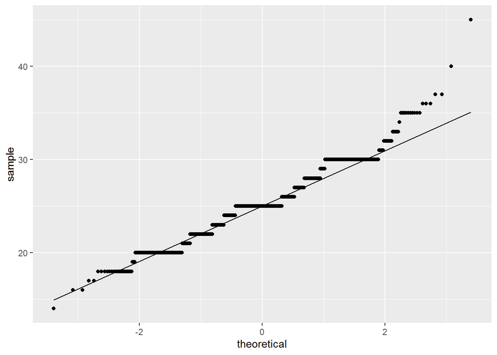

```r
ggplot(Hu_v3.0, aes(sample = ideal_marriage_age)) +
  stat_qq() +
  stat_qq_line()
```

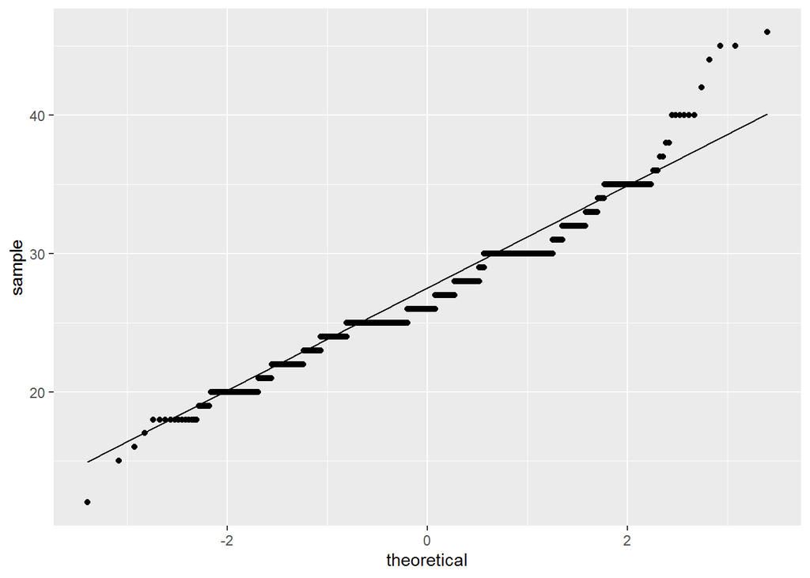

```r
ggplot(Hu_v3.0, aes(sample = ideal_parenthood_age)) +
  stat_qq() +
  stat_qq_line()
```

On both plots, the points significantly deviate from the line. This indicates that the *variable is not normally allocated*. + Also we can see right skew of data outlines in both cases.

*Determine normality with describe function*

```r
Hu_v4.0 <- describe(Hu_v3.0)
Hu_v4.0<- Hu_v4.0 %>%  select(-vars,-n,-sd,-trimmed,-mad,-range,-se,-mean,-median,-min,-max)
Hu_v4.0
```

```
##                      skew kurtosis
## ideal_marriage_age   0.38     1.10
## ideal_parenthood_age 0.55     1.83
```

**Shapiro-Wilk tests of normality.**

Test #1 Null hypothesis: The data is normally distributed. Alternative hypothesis: The data is not normally distributed.

```r
shapiro.test(Hu_v3.0$ideal_marriage_age)
```

```
##
##  Shapiro-Wilk normality test
##
## data:  Hu_v3.0$ideal_marriage_age
## W = 0.95819, p-value < 2.2e-16
```

In this case p < 0.00000024 < 0.05, so we reject the null hypothesis and assume, that data is not normally distributed.

Test #2 Null hypothesis: The data is normally distributed. Alternative hypothesis: The data is not normally distibuted.

```r
shapiro.test(Hu_v3.0$ideal_parenthood_age)
```

```
##
##  Shapiro-Wilk normality test
##
## data:  Hu_v3.0$ideal_parenthood_age
## W = 0.95867, p-value < 2.2e-16
```

In this case p < 0.00000024 < 0.05, so we reject the null hypothesis and assume, that data is not normally distributed.

For both variables, the distribution in not normal for sure. However, it is not a big problem, since T-test in quite robust to non-normality if the sample is large. But we need to remember, that in this case Type 1 risk increases.

Testing: *Variance equality* Simple calculations:

```r
var(Hu_v3.0$ideal_parenthood_age)
```

```
## [1] 14.09916
```

```r
var(Hu_v3.0$ideal_marriage_age)
```

```
## [1] 11.17243
```

So it is obvious, that variances are not equal.

Time to perform **T-test**. Since we have to check independent samples, which have not equal variance, the best option - is to use Welch t-test.

Let’s remind hypothesis: Null hypothesis: the mean values of ideal_marriage_age and ideal_parenthood_age are equal. Alternative hypothesis: the mean values of ideal_marriage_age and ideal_parenthood_age not equal.

```r
t.test(Hu_v3.0$ideal_marriage_age, Hu_v3.0$ideal_parenthood_age, paired = FALSE, var.equal = FALSE)
```

```
##
##  Welch Two Sample t-test
##
## data:  Hu_v3.0$ideal_marriage_age and Hu_v3.0$ideal_parenthood_age
## t = -11.638, df = 2883.3, p-value < 2.2e-16
## alternative hypothesis: true difference in means is not equal to 0
## 95 percent confidence interval:
##  -1.787890 -1.272302
## sample estimates:
## mean of x mean of y
##  25.28659  26.81669
```

since p < 0.00000024 < 0.05, we reject the null hypothesis. Sо values of sample are not equal. Since t= -11.638, the difference is statistically significant.

*Effect size:*

```r
cohensD(Hu_v3.0$ideal_marriage_age, Hu_v3.0$ideal_parenthood_age)
```

```
## [1] 0.4304447
```

So, Effect size variable = 0.4304447, so the effect size is medium.

Now let’s double check the result with **non-parametric Wilcoxon Rank-Sum Test**.

Null hypothesis: the mean values of ideal_marriage_age and ideal_parenthood_age are equal. Alternative hypothesis: the mean values of ideal_marriage_age and ideal_parenthood_age not equal.

```r
wilcox.test(Hu_v3.0$ideal_marriage_age, Hu_v3.0$ideal_parenthood_age, paired = FALSE, conf.int = TRUE)
```

```
##
##  Wilcoxon rank sum test with continuity correction
##
## data:  Hu_v3.0$ideal_marriage_age and Hu_v3.0$ideal_parenthood_age
## W = 808108, p-value < 2.2e-16
## alternative hypothesis: true location shift is not equal to 0
## 95 percent confidence interval:
##  -1.999948 -1.000043
## sample estimates:
## difference in location
##              -1.000001
```

since p < 0.00000024 < 0.05, we reject the null hypothesis. So mean values of ideal_marriage_age and ideal_parenthood_age not equal. *This corresponds to the results of the Welch t-test*.

## ANOVA

For one-way ANOVA test we decided to analyze relationship between the *Age of first marriage* (`mrage`) and the *Place of living* (`domicil`). Thus, we took a numeric and categorical variables. So, we creating a subset with necessary variables and exclude all NAs.

```r
mar <- hu [c("mrage", "domicil")]
mar1 <- na.omit(mar)
```

Thus, our *substantial hypothesis* is the following: We expect the difference between the marriage ages of people who live in big cities and small towns and villages, as the second ones tend to have more traditional views and less opportunities (like ability to get higher education or build a career).

Now, we want to see the distribution of answers among participants.

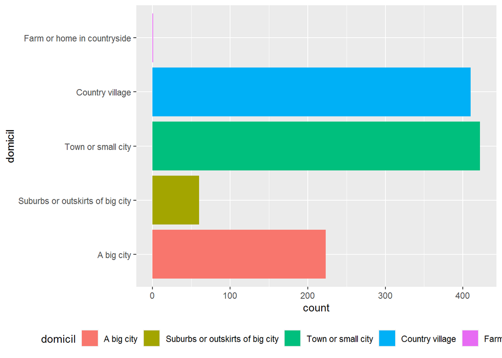

```r
ggplot(mar1) +
  geom_bar(mapping = aes(domicil, fill=domicil)) +
  theme(legend.position = "bottom") +
  coord_flip()
```

As we can observe, unfortunately, the number of participants from different places of residence is highly unequal. So in order to decrease bias we used **filter** function. Thus, we excluded people, who live in a “farm or home in countryside”, as the it is too small.

```r
hu_aov <- filter(mar1, mar1$domicil != "Farm or home in countryside")
```

Now, let’s proceed to the *boxplot* with corrected dataset.

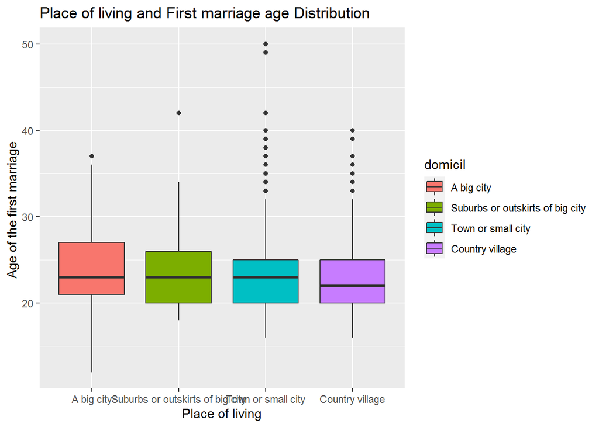

```r
ggplot(hu_aov) +
  geom_boxplot(aes(x=domicil, y=mrage, fill=domicil)) +
  xlab("Place of living") +
  ylab("Age of the first marriage ") +
  ggtitle("Place of living and First marriage age Distribution") +
  guides(legend = "none")
```

The difference seems to be small, but we should check it by the tests. After we defined the variables, we can state *hypotheses*. H0: **All means are equal** => there is *no difference* between mean ages of the first marriage among different places of residence. Ha: There is *at least one difference* among means. So, probably at least one type of residence has higher or smaller age of the first marriage.

**Attention please!** As we mentioned earlier, sample here is unequal, so suburbs or outskirt of big city is significantly smaller than others. This means that results might be biased.

Next, we have to check the **homogeneity of variances**, in order to be sure that we can conduct ANOVA test. We prefer *Levene’s test* for this case. So, we have the following hypotheses. H0: *The variances are homogeneous* => variances are equal Ha: *Variances are* **not** *homogeneous* => there is at least one difference among variances

```r
leveneTest(mrage ~ domicil, data = hu_aov)
```

```
## Levene's Test for Homogeneity of Variance (center = median)
##         Df F value Pr(>F)
## group    3  0.8837 0.4489
##       1111
```

From the output above we can see that the *p-value* (0.4489) is higher than the significance level of 0.05. So we cannot reject the null hypothesis => This means that we can assume the homogeneity of variances.

Now, let’s check the **Normality assumption**

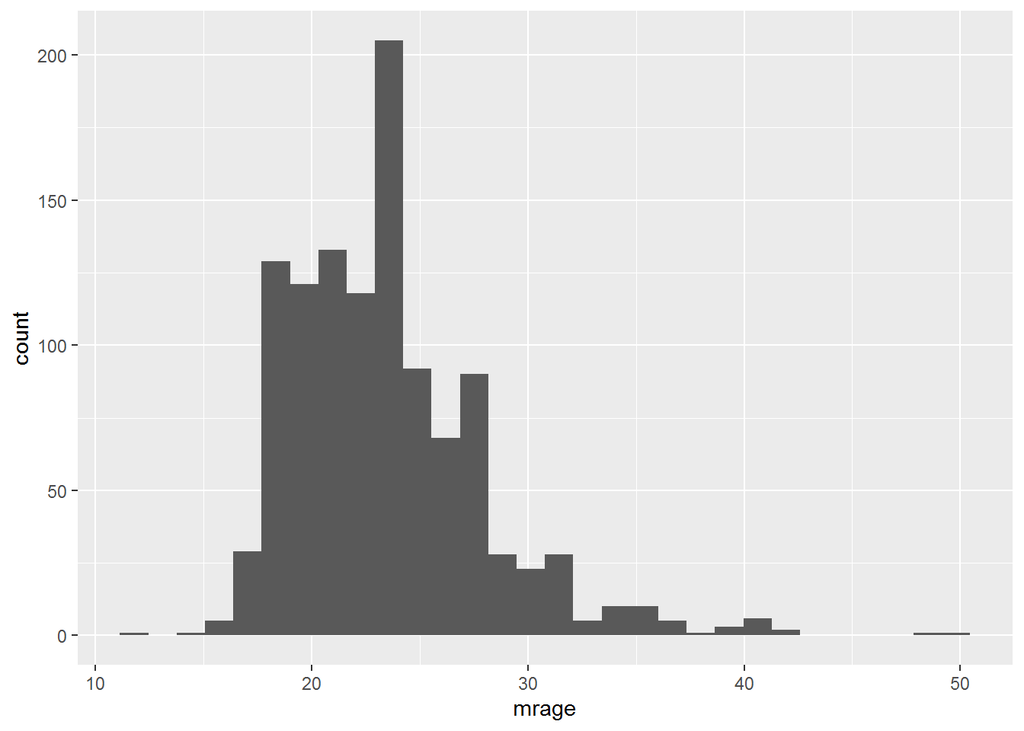

```r
ggplot(hu_aov, aes(mrage)) +
  geom_histogram()
```

According to the graph, we can see, that “age of marriage” (`mrage`) variable distributed not normally.

```r
describeBy(hu_aov, hu_aov$domicil)
```

```
##
##  Descriptive statistics by group
## group: A big city
##          vars   n  mean   sd median trimmed  mad min max range skew kurtosis
## mrage       1 223 23.91 4.11     23   23.64 4.45  12  37    25 0.59     0.44
## domicil*    2 223  1.00 0.00      1    1.00 0.00   1   1     0  NaN      NaN
##            se
## mrage    0.28
## domicil* 0.00
## ------------------------------------------------------------
## group: Suburbs or outskirts of big city
##          vars  n mean   sd median trimmed  mad min max range skew kurtosis   se
## mrage       1 60 23.5 4.45     23   23.02 4.45  18  42    24 1.37     3.18 0.57
## domicil*    2 60  2.0 0.00      2    2.00 0.00   2   2     0  NaN      NaN 0.00
## ------------------------------------------------------------
## group: Town or small city
##          vars   n  mean   sd median trimmed  mad min max range skew kurtosis
## mrage       1 422 23.63 4.77     23   23.05 4.45  16  50    34  1.7     4.82
## domicil*    2 422  3.00 0.00      3    3.00 0.00   3   3     0  NaN      NaN
##            se
## mrage    0.23
## domicil* 0.00
## ------------------------------------------------------------
## group: Country village
##          vars   n  mean   sd median trimmed  mad min max range skew kurtosis
## mrage       1 410 23.04 4.21     22   22.57 2.97  16  40    24 1.29     2.48
## domicil*    2 410  4.00 0.00      4    4.00 0.00   4   4     0  NaN      NaN
##            se
## mrage    0.21
## domicil* 0.00
## ------------------------------------------------------------
## group: Farm or home in countryside
## NULL
```

Here we check the normality for each of 4 subsets of age_of_marriage by `domicil`. And in each one the *distribution in not normal*, because skew do not belong to [-0.5; 0.5].

In spite the absence of normality assumption, we we can try to run the *one-way ANOVA test* for our variables.

```r
anova <- aov(mrage ~ domicil, data = hu_aov)
tidy(anova)
```

```
## # A tibble: 2 x 6
##   term         df  sumsq meansq statistic p.value
##   <chr>     <dbl>  <dbl>  <dbl>     <dbl>   <dbl>
## 1 domicil       3   127.   42.3      2.17  0.0905
## 2 Residuals  1111 21718.   19.5     NA    NA
```

```r
summary(anova)
```

```
##               Df Sum Sq Mean Sq F value Pr(>F)
## domicil        3    127   42.33   2.165 0.0905 .
## Residuals   1111  21718   19.55
## ---
## Signif. codes:  0 '***' 0.001 '**' 0.01 '*' 0.05 '.' 0.1 ' ' 1
```

P-value here is significantly bigger than 0.05 => *we cannot reject the null hypothesis* (that all means are equal). However, we can’t trust to this test, as the distribution of variables is not normal => there are might be a biased

This way, to double-check the results of F-test we run the **Non-parametric test**

```r
kruskal.test(mrage ~ domicil, data = hu_aov)
```

```
##
##  Kruskal-Wallis rank sum test
##
## data:  mrage by domicil
## Kruskal-Wallis chi-squared = 8.7921, df = 3, p-value = 0.03219
```

The output here shows that p-value is smaller that 0.05 => that proves that our previous test was biased. So **we reject the null hypothesis**. It assumes that there is a difference among marriage ages of people from differenr places of residence.

To sum up one-way ANOVA test, we’d like to check the effect size.

```r
kruskal_effsize(data = hu_aov, mrage ~ domicil)
```

```
## # A tibble: 1 x 5
##   .y.       n effsize method  magnitude
## * <chr> <int>   <dbl> <chr>   <ord>
## 1 mrage  1115 0.00521 eta2[H] small
```

As we may see, that effect size is small.

```r
games_howell_test(mrage ~ domicil, data = hu_aov)
```

```
## # A tibble: 6 x 8
##   .y.   group1       group2       estimate conf.low conf.high p.adj p.adj.signif
## * <chr> <chr>        <chr>           <dbl>    <dbl>     <dbl> <dbl> <chr>
## 1 mrage A big city   Suburbs or ~   -0.406    -2.07    1.26   0.92  ns
## 2 mrage A big city   Town or sma~   -0.280    -1.21    0.648  0.864 ns
## 3 mrage A big city   Country vil~   -0.862    -1.75    0.0270 0.061 ns
## 4 mrage Suburbs or ~ Town or sma~    0.126    -1.50    1.75   0.997 ns
## 5 mrage Suburbs or ~ Country vil~   -0.456    -2.06    1.15   0.878 ns
## 6 mrage Town or sma~ Country vil~   -0.582    -1.38    0.220  0.243 ns
```

As we may see, all cases are not statistically significant. This way, we may conclude that there is no difference between variables.

## Conclusion

To sum up, we conducted several tests to check our hypotheses on socio-demographic characteristics of Hungarian citizens. With the help of chi-squared test we found out that there is an overall correlation between the gender of a person and his/her form of employment. For example, Hungarian males more frequently become self-employed than do females. Then, with the help of t-test we found that the ideal marital age of a person and ideal age of becoming a parent are not equal. In general, ideal age of becoming a parent comes later than the perfect marital age. Finally, we checked our last assumption on the relationship between the age of first marriage and person’s place of living, using ANOVA test. There, we found out that place of living does not reflect muh the marital age (however, the small correlation exists). Thus, we analyzed different features peculiar for Hungarian citizens

# Project 3: Correlation & Linear Regression

## Research area

In this project we decided to concentrate on the politics of Hungary. Thus, we tried to explore the data on political views of Hungarian citizens and find some patterns that influence the peoples’ views on government.

### Research question

Therefore, our research question for this project is the following: *Which factors may predict peoples’ satisfaction with government?*

## Variables

### Selecting and Editing Variables: Creating a Subset

```r
Pr3_Hu_v.2.0 <- Hungary [c("stfgov","lrscale", "stfeco", "stfdem", "gvintcz" )]
Pr3_Hu_v.2.1 <- Pr3_Hu_v.2.0
levels(Pr3_Hu_v.2.1$stfgov)[match("Extremely dissatisfied",levels(Pr3_Hu_v.2.1$stfgov))] <- "0"
levels(Pr3_Hu_v.2.1$stfgov)[match("Extremely satisfied",levels(Pr3_Hu_v.2.1$stfgov))] <- "10"
levels(Pr3_Hu_v.2.1$lrscale)[match("Left",levels(Pr3_Hu_v.2.1$lrscale))] <- "0"
levels(Pr3_Hu_v.2.1$lrscale)[match("Right",levels(Pr3_Hu_v.2.1$lrscale))] <- "10"
levels(Pr3_Hu_v.2.1$stfeco)[match("Extremely dissatisfied",levels(Pr3_Hu_v.2.1$stfeco))] <- "0"
levels(Pr3_Hu_v.2.1$stfeco)[match("Extremely satisfied",levels(Pr3_Hu_v.2.1$stfeco))] <- "10"
levels(Pr3_Hu_v.2.1$stfdem)[match("Extremely dissatisfied",levels(Pr3_Hu_v.2.1$stfdem))] <- "0"
levels(Pr3_Hu_v.2.1$stfdem)[match("Extremely satisfied",levels(Pr3_Hu_v.2.1$stfdem))] <- "10"

Pr3_Hu_v.2.1 <- na.omit(Pr3_Hu_v.2.1)
```

### Description of variables

We decided to chose the following **variables**:

*continuous* `stfgov` (ordinal) - How satisfied with the national government `stfeco` (ordinal) - How satisfied with present state of economy in country `stfdem` (ordinal) - How satisfied with the way democracy works in country All these variables have the same answer scale that starts from “Extremely dissatisfied”, than follows as 1 to 9 spectrum and ends with “Extremely satisfied”.

`lrscale`(interval) - Placement on left/right political views scale from “Left” to 1 - 9 spectrum, and then to “Right”. To make these variables exclusively numeric (this is necessary for the correlation matrix), we changed the outside answers from words to numbers: 0 and 10, respectively.

*categorical* `gvintcz` (ordinal) - Does government take into account the interest of all citizens (from “Not at all” to a “Great deal”)

Finally, we exclude lines with NA variables (thus we loose 323 rows from original set) and here it is our subset(table).

### Checking the type of variables:

```r
class(Pr3_Hu_v.2.1$stfgov)
```

```
## [1] "factor"
```

```r
class(Pr3_Hu_v.2.1$lrscale)
```

```
## [1] "factor"
```

```r
class(Pr3_Hu_v.2.1$stfeco)
```

```
## [1] "factor"
```

```r
class(Pr3_Hu_v.2.1$stfdem)
```

```
## [1] "factor"
```

```r
class(Pr3_Hu_v.2.1$gvintcz)
```

```
## [1] "factor"
```

### Changing continues variables data type from factor to numeric. And re-check it.

```r
Pr3_Hu_v.2.1$stfgov <- as.numeric(as.character(Pr3_Hu_v.2.1$stfgov))
Pr3_Hu_v.2.1$lrscale <- as.numeric(as.character(Pr3_Hu_v.2.1$lrscale))
Pr3_Hu_v.2.1$stfeco <- as.numeric(as.character(Pr3_Hu_v.2.1$stfeco))
Pr3_Hu_v.2.1$stfdem <- as.numeric(as.character(Pr3_Hu_v.2.1$stfdem))

class(Pr3_Hu_v.2.1$stfgov)
```

```
## [1] "numeric"
```

```r
class(Pr3_Hu_v.2.1$lrscale)
```

```
## [1] "numeric"
```

```r
class(Pr3_Hu_v.2.1$stfeco)
```

```
## [1] "numeric"
```

```r
class(Pr3_Hu_v.2.1$stfdem)
```

```
## [1] "numeric"
```

```r
class(Pr3_Hu_v.2.1$gvintcz)
```

```
## [1] "factor"
```

It is fine.

### Renaming variables in the table for better layout

```r
Pr3_Hu_v.2.1 <- Pr3_Hu_v.2.1 %>% rename(peoples_satisfaction_with_government=stfgov, left_right_views_of_people=lrscale, peoples_satisfaction_with_economy=stfeco, peoples_satisfaction_with_democracy=stfdem, peoples_view_whether_the_government_takes_into_account_interests_of_people=gvintcz)
```

### Creating two subets from our table, that will use for specific purposes(graph and correlation matrix, linear regression models) in the future.

```r
Pr3_Hu_v.3.1 <- Pr3_Hu_v.2.1 %>%  select(-peoples_view_whether_the_government_takes_into_account_interests_of_people)
Pr3_Hu_v.3.2 <- Pr3_Hu_v.2.1 %>%  select(-left_right_views_of_people, -peoples_satisfaction_with_economy, -peoples_satisfaction_with_democracy)
Pr3_Hu_v.3.3 <- Pr3_Hu_v.2.1 %>% select(-left_right_views_of_people)
```

## Descriptive statistics

```r
describe(Pr3_Hu_v.2.1)
```

```
##                                                                             vars
## peoples_satisfaction_with_government                                           1
## left_right_views_of_people                                                     2
## peoples_satisfaction_with_economy                                              3
## peoples_satisfaction_with_democracy                                            4
## peoples_view_whether_the_government_takes_into_account_interests_of_people*    5
##                                                                                n
## peoples_satisfaction_with_government                                        1338
## left_right_views_of_people                                                  1338
## peoples_satisfaction_with_economy                                           1338
## peoples_satisfaction_with_democracy                                         1338
## peoples_view_whether_the_government_takes_into_account_interests_of_people* 1338
##                                                                             mean
## peoples_satisfaction_with_government                                        4.62
## left_right_views_of_people                                                  5.36
## peoples_satisfaction_with_economy                                           4.84
## peoples_satisfaction_with_democracy                                         4.60
## peoples_view_whether_the_government_takes_into_account_interests_of_people* 2.43
##                                                                               sd
## peoples_satisfaction_with_government                                        2.74
## left_right_views_of_people                                                  2.57
## peoples_satisfaction_with_economy                                           2.33
## peoples_satisfaction_with_democracy                                         2.68
## peoples_view_whether_the_government_takes_into_account_interests_of_people* 1.06
##                                                                             median
## peoples_satisfaction_with_government                                             5
## left_right_views_of_people                                                       5
## peoples_satisfaction_with_economy                                                5
## peoples_satisfaction_with_democracy                                              5
## peoples_view_whether_the_government_takes_into_account_interests_of_people*      2
##                                                                             trimmed
## peoples_satisfaction_with_government                                           4.64
## left_right_views_of_people                                                     5.40
## peoples_satisfaction_with_economy                                              4.88
## peoples_satisfaction_with_democracy                                            4.64
## peoples_view_whether_the_government_takes_into_account_interests_of_people*    2.37
##                                                                              mad
## peoples_satisfaction_with_government                                        2.97
## left_right_views_of_people                                                  2.97
## peoples_satisfaction_with_economy                                           2.97
```

[output cut: 23 more lines]

```
## peoples_satisfaction_with_economy                                           -0.09
## peoples_satisfaction_with_democracy                                         -0.06
## peoples_view_whether_the_government_takes_into_account_interests_of_people*  0.28
##                                                                             kurtosis
## peoples_satisfaction_with_government                                           -0.93
## left_right_views_of_people                                                     -0.34
## peoples_satisfaction_with_economy                                              -0.50
## peoples_satisfaction_with_democracy                                            -0.88
## peoples_view_whether_the_government_takes_into_account_interests_of_people*    -0.56
##                                                                               se
## peoples_satisfaction_with_government                                        0.07
## left_right_views_of_people                                                  0.07
## peoples_satisfaction_with_economy                                           0.06
## peoples_satisfaction_with_democracy                                         0.07
## peoples_view_whether_the_government_takes_into_account_interests_of_people* 0.03
```

### Interpretation of descriptive statistics

First of all, for each variable (that are presented in the first column), tha data is not skewed (since coefficient<+-1).So highly likely the data is close to normal distribution Than, by looking at kurtosis, it can be noted, that the distribution for all variables has a fairly smooth peak. Mean and median for first 4 variables are really close to each other (~5). This generally suggests that people on average have moderate (~5/10) satisfaction with government, economy and democracy, and also have approximately equal numbers of both left and right views (with a slight margin towards the right). If we look at their opinion on whether the government takes into account the opinion of citizens, then the average indicators will not be high (THey do, but quite a bit=“some”. ~2/5 median and 2.43/5 mean).

## Our expectations:

Before we proceed to the analysis, we have to state our **expectations**.

We assume that there will be a *positive correlation* between satisfaction with government and political views of a person, so the more right views one has, the more he/she will be satisfied with the government (Because the Hungarian government has been more right-wing for the last 10 years).

We also expect that there might be a *positive correlation* between satisfaction with government and satisfaction with a present state of economy in country. We think that for people one of the criteria for the success of a government is a good economy and vice versa: bad economy is fail of government.

The third correlation we expect is also *positive* and a little bit obvious. So, we suppose that, as in previous cases, the more satisfied person with the way democracy works in country, the more he or she will be satisfied with the government.

And the last, but not the least correlation we expect is a *positive correlation* of continuous and categorical variables, namely the government satisfaction and believes that government takes into account all citizens interests. As people who are really dissatisfied with it probably believe that government don’t take their views and problems into account.

## Analysis

### Correlation matrix

Before the creation of the correlation matrix, we should check for normality. We do is for all the variables with Shapiro-Wilk Test

```r
shapiro.test(Pr3_Hu_v.3.1$peoples_satisfaction_with_government)
```

```
##
##  Shapiro-Wilk normality test
##
## data:  Pr3_Hu_v.3.1$peoples_satisfaction_with_government
## W = 0.9598, p-value < 2.2e-16
```

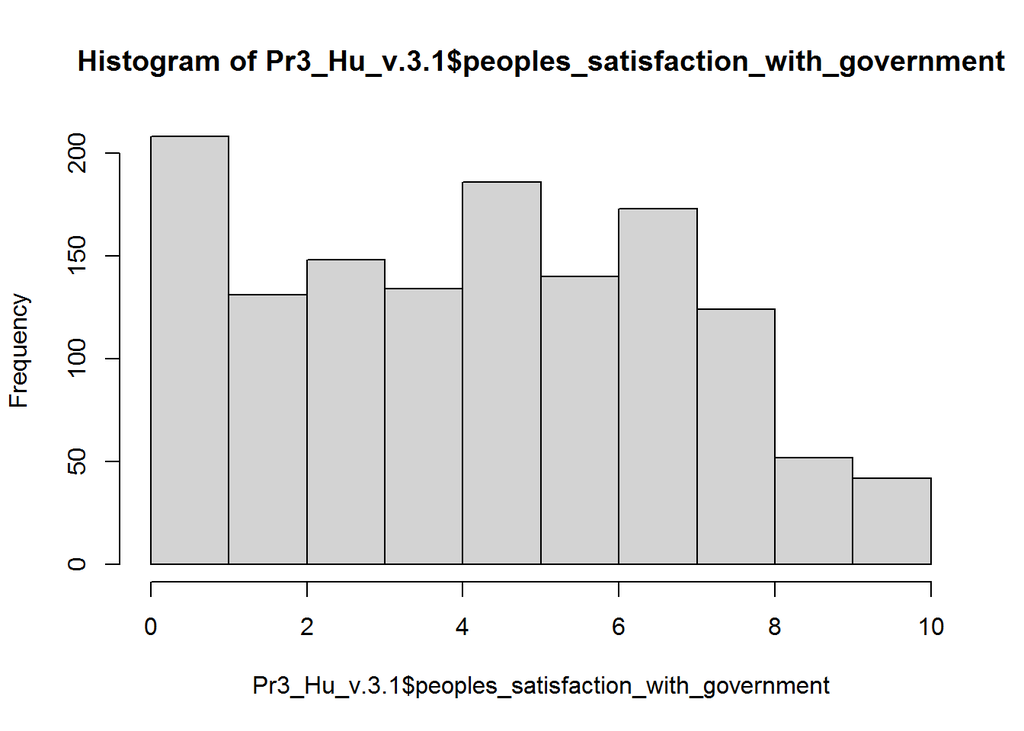

```r
hist(Pr3_Hu_v.3.1$peoples_satisfaction_with_government)
```

```r
shapiro.test(Pr3_Hu_v.3.1$peoples_satisfaction_with_economy)
```

```
##
##  Shapiro-Wilk normality test
##
## data:  Pr3_Hu_v.3.1$peoples_satisfaction_with_economy
## W = 0.97479, p-value = 1.534e-14
```

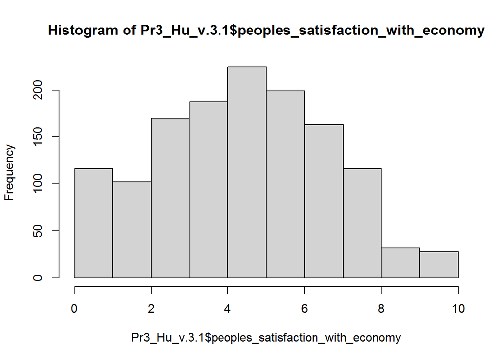

```r
hist(Pr3_Hu_v.3.1$peoples_satisfaction_with_economy)
```

```r
shapiro.test(Pr3_Hu_v.3.1$peoples_satisfaction_with_democracy)
```

```
##
##  Shapiro-Wilk normality test
##
## data:  Pr3_Hu_v.3.1$peoples_satisfaction_with_democracy
## W = 0.96183, p-value < 2.2e-16
```

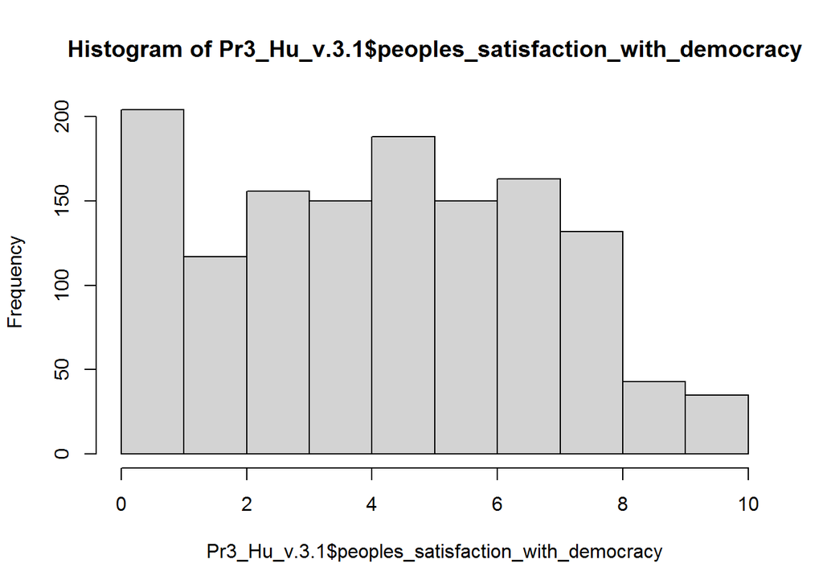

```r
hist(Pr3_Hu_v.3.1$peoples_satisfaction_with_democracy)
```

```r
shapiro.test(Pr3_Hu_v.3.1$left_right_views_of_people)
```

```
##
##  Shapiro-Wilk normality test
##
## data:  Pr3_Hu_v.3.1$left_right_views_of_people
## W = 0.95744, p-value < 2.2e-16
```

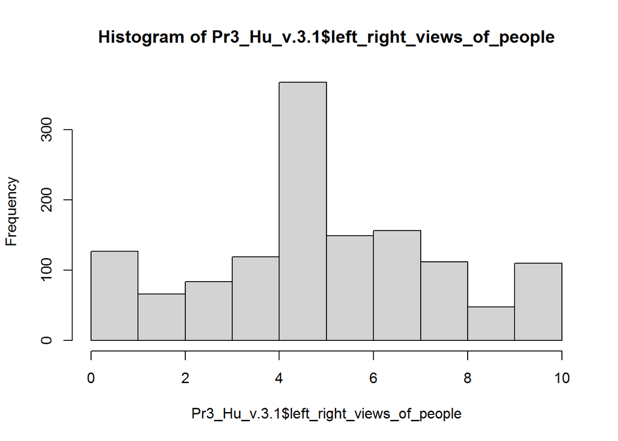

```r
hist(Pr3_Hu_v.3.1$left_right_views_of_people)
```

We can see that the p-values for Shapiro-Wilk normality tests are less than 0,05 -> therefore, we may conclude that the data is not normally distributed. Therefore, we cannot apply Pearson’s product moment correlation. Instead, we will use Spearman’s rank correlation coefficient.

Now we can create a correlation matrix

```r
tab_corr(Pr3_Hu_v.3.1, digits = 2,
         corr.method = "spearman")
```

|  | peoples_satisfaction_with_government | left_right_views_of_people | peoples_satisfaction_with_economy | peoples_satisfaction_with_democracy |
| --- | --- | --- | --- | --- |
| peoples_satisfaction_with_government |  | 0.49*** | 0.81*** | 0.84*** |
| left_right_views_of_people | 0.49*** |  | 0.47*** | 0.47*** |
| peoples_satisfaction_with_economy | 0.81*** | 0.47*** |  | 0.74*** |
| peoples_satisfaction_with_democracy | 0.84*** | 0.47*** | 0.74*** |  |
| Computed correlation used spearman-method with listwise-deletion. |  |  |  |  |

### Interpretation of a correlation matrix

In the matrix we may see several positively strong correlation among variables. The strongest is observed between `peoples_satisfaction_with_democracy` (predictor) and `peoples_satisfaction_with_government` (outcome). This is the correlation we can consider significant (0.84). Apart from that, we see a statistically strong positive correlation between `peoples_satisfaction_with_economy` (predictor) and the same outcome `peoples_satisfaction_with_government` (0,81). The last correlation between `left_right_views_of_people` and `peoples_satisfaction_with_government` is a medium positive correlation (0.49), which we won’t take for the further analysis.

### Boxplot

Next, we will create a box plot with a categorical predictor (`peoples_view_whether_the_government_takes_into_account_interests_of_people`) and the same continuous outcome (`peoples_satisfaction_with_government`). To make this, we use a dataset containing this two variables

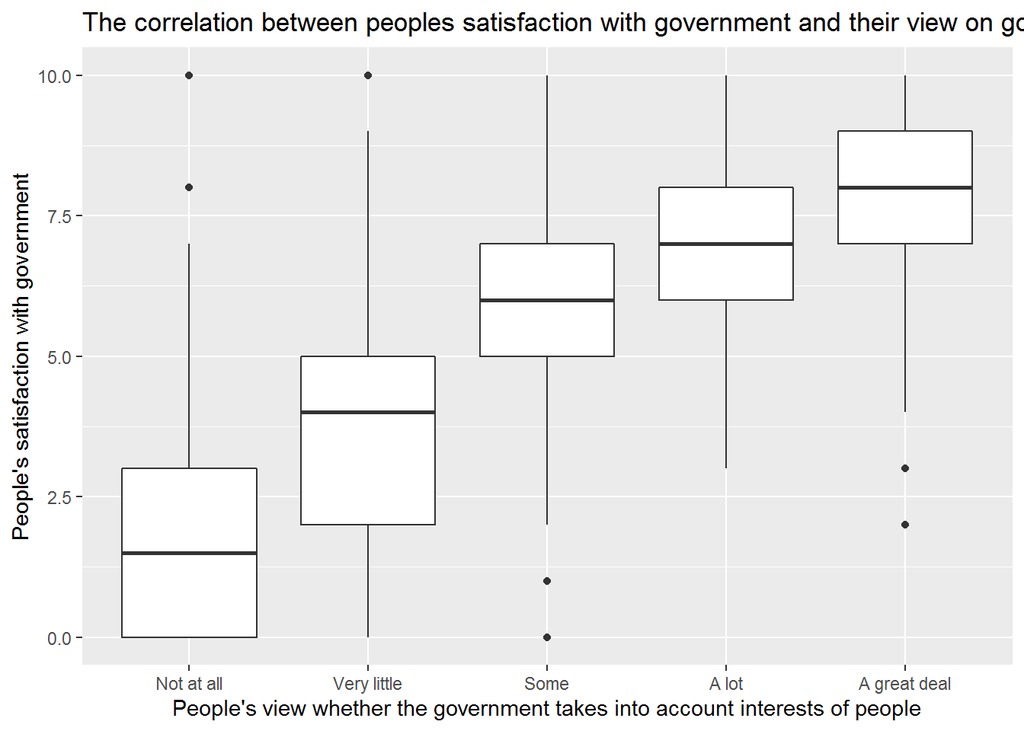

```r
ggplot(Pr3_Hu_v.3.2) +
geom_boxplot(aes(x=peoples_view_whether_the_government_takes_into_account_interests_of_people, y=peoples_satisfaction_with_government)) +
xlab("People's view whether the government takes into account interests of people") +
ylab("People's satisfaction with government") +
ggtitle("The correlation between peoples satisfaction with government and their view on governmental activity")
```

## Regression model

Next, we build the **regression model** with the significant co-variate (peoples satisfaction with democracy as a predictor to the peoples satisfaction with government) First, we once again look at the given correlation (in the more detailed way), using * Spearman’s rank correlation*.

```r
cor.test(Pr3_Hu_v.3.1$peoples_satisfaction_with_government, Pr3_Hu_v.3.1$peoples_satisfaction_with_democracy, method = "spearman")
```

```
##
##  Spearman's rank correlation rho
##
## data:  Pr3_Hu_v.3.1$peoples_satisfaction_with_government and Pr3_Hu_v.3.1$peoples_satisfaction_with_democracy
## S = 64116438, p-value < 2.2e-16
## alternative hypothesis: true rho is not equal to 0
## sample estimates:
##       rho
## 0.8393974
```

### Next, we also plot the correlation

[figure not shown]

```r
ggplot(Pr3_Hu_v.3.1, aes(x = peoples_satisfaction_with_democracy, y = peoples_satisfaction_with_government)) +
geom_jitter() +
labs(x = "Peoples satisfaction with government", y = "Peoples satisfaction with democracy") + ggtitle("The correlation between people's satisfaction with government and with democracy")
```

### Now we create a *regression model*

```r
model1 <- lm(peoples_satisfaction_with_government ~ peoples_satisfaction_with_democracy, data = Pr3_Hu_v.3.1)
summary(model1)
```

```
##
## Call:
## lm(formula = peoples_satisfaction_with_government ~ peoples_satisfaction_with_democracy,
##     data = Pr3_Hu_v.3.1)
##
## Residuals:
##     Min      1Q  Median      3Q     Max
## -7.5366 -0.6786  0.0375  0.7472  9.3278
##
## Coefficients:
##                                     Estimate Std. Error t value Pr(>|t|)
## (Intercept)                          0.67216    0.08160   8.237 4.16e-16 ***
## peoples_satisfaction_with_democracy  0.85806    0.01534  55.940  < 2e-16 ***
## ---
## Signif. codes:  0 '***' 0.001 '**' 0.01 '*' 0.05 '.' 0.1 ' ' 1
##
## Residual standard error: 1.501 on 1336 degrees of freedom
## Multiple R-squared:  0.7008, Adjusted R-squared:  0.7006
## F-statistic:  3129 on 1 and 1336 DF,  p-value: < 2.2e-16
```

### Interpretation of the model and its comparison with the correlation coefficient

Here we observe that the p-value is very small (<0.001), which means we can reject the null hypothesis and confirm that there is a non-zero correlation between variables. We also see that R-squared equals 0,7008, which shows a strong predictive power (>0.1).

Now to the coefficients. The correlation coefficient is a square root of R-squared (~0,83), which shows positively strong statistically significant correlation. The regression coefficient is 0.858. Therefore, we may say that a person who scores an additional point higher on the satisfaction with democracy is predicted to score 0.858 higher on satisfaction with government, on average

## Hierarchical regression model

```r
model1 <- lm(peoples_satisfaction_with_government ~ peoples_satisfaction_with_democracy, data = Pr3_Hu_v.3.3)
model2 <- lm(peoples_satisfaction_with_government ~ peoples_satisfaction_with_democracy + peoples_satisfaction_with_economy, data = Pr3_Hu_v.3.3)
model3 <- lm(peoples_satisfaction_with_government ~ peoples_satisfaction_with_democracy + peoples_satisfaction_with_economy + peoples_view_whether_the_government_takes_into_account_interests_of_people, data = Pr3_Hu_v.3.3)
tab_model(model3, show.ci = F)
```

|  | peoples_satisfaction_with_government |  |
| --- | --- | --- |
| Predictors | Estimates | p |
| (Intercept) | -0.23 | **0.010** |
| peoples_satisfaction_with_democracy | 0.48 | **<0.001** |
| peoples_satisfaction_with_economy | 0.47 | **<0.001** |
| peoples_view_whether_the_government_takes_into_account_interests_of_people [Very little] | 0.12 | 0.245 |
| peoples_view_whether_the_government_takes_into_account_interests_of_people [Some] | 0.51 | **<0.001** |
| peoples_view_whether_the_government_takes_into_account_interests_of_people [A lot] | 0.87 | **<0.001** |
| peoples_view_whether_the_government_takes_into_account_interests_of_people [A great deal] | 1.10 | **<0.001** |
| Observations | 1338 |  |
| R<sup>2</sup> / R<sup>2</sup> adjusted | 0.791 / 0.790 |  |

```r
anova(model1, model2, model3)
```

```
## Analysis of Variance Table
##
## Model 1: peoples_satisfaction_with_government ~ peoples_satisfaction_with_democracy
## Model 2: peoples_satisfaction_with_government ~ peoples_satisfaction_with_democracy +
##     peoples_satisfaction_with_economy
## Model 3: peoples_satisfaction_with_government ~ peoples_satisfaction_with_democracy +
##     peoples_satisfaction_with_economy + peoples_view_whether_the_government_takes_into_account_interests_of_people
##   Res.Df    RSS Df Sum of Sq       F    Pr(>F)
## 1   1336 3008.7
## 2   1335 2184.8  1    823.86 521.632 < 2.2e-16 ***
## 3   1331 2102.2  4     82.62  13.078 1.889e-10 ***
## ---
## Signif. codes:  0 '***' 0.001 '**' 0.01 '*' 0.05 '.' 0.1 ' ' 1
```

### Interpretation of the model

We look at the Analysis of Variance table to decide which model fits better. We can say that the *3rd model is the best model fit*. First, we look at the Degrees of freedom (Df), which tells us that in the last model we estimate 4 parameters. Also, RSS tells us how much was left unexplained, therefore the smaller RSS is better for model fit. Besides that, we can see that stars (referring to F-statistic) tell us the last model is better than the 2nd model (as well, as the 2nd model is better than the 1st). Therefore, we can conclude model 3 fits the data the best

## The best model summary

```r
summary(model3)
```

```
##
## Call:
## lm(formula = peoples_satisfaction_with_government ~ peoples_satisfaction_with_democracy +
##     peoples_satisfaction_with_economy + peoples_view_whether_the_government_takes_into_account_interests_of_people,
##     data = Pr3_Hu_v.3.3)
##
## Residuals:
##     Min      1Q  Median      3Q     Max
## -6.5098 -0.6744  0.0206  0.5494  8.3416
##
## Coefficients:
##                                                                                        Estimate
## (Intercept)                                                                            -0.22639
## peoples_satisfaction_with_democracy                                                     0.48382
## peoples_satisfaction_with_economy                                                       0.47119
## peoples_view_whether_the_government_takes_into_account_interests_of_peopleVery little   0.12031
## peoples_view_whether_the_government_takes_into_account_interests_of_peopleSome          0.50805
## peoples_view_whether_the_government_takes_into_account_interests_of_peopleA lot         0.86884
## peoples_view_whether_the_government_takes_into_account_interests_of_peopleA great deal  1.09608
##                                                                                        Std. Error
## (Intercept)                                                                               0.08753
## peoples_satisfaction_with_democracy                                                       0.02074
## peoples_satisfaction_with_economy                                                         0.02260
## peoples_view_whether_the_government_takes_into_account_interests_of_peopleVery little     0.10343
## peoples_view_whether_the_government_takes_into_account_interests_of_peopleSome            0.11324
## peoples_view_whether_the_government_takes_into_account_interests_of_peopleA lot           0.15299
## peoples_view_whether_the_government_takes_into_account_interests_of_peopleA great deal    0.22627
##                                                                                        t value
## (Intercept)                                                                             -2.586
## peoples_satisfaction_with_democracy                                                     23.329
## peoples_satisfaction_with_economy                                                       20.846
## peoples_view_whether_the_government_takes_into_account_interests_of_peopleVery little    1.163
## peoples_view_whether_the_government_takes_into_account_interests_of_peopleSome           4.487
## peoples_view_whether_the_government_takes_into_account_interests_of_peopleA lot          5.679
## peoples_view_whether_the_government_takes_into_account_interests_of_peopleA great deal   4.844
##                                                                                        Pr(>|t|)
## (Intercept)                                                                              0.0098
## peoples_satisfaction_with_democracy                                                     < 2e-16
## peoples_satisfaction_with_economy                                                       < 2e-16
## peoples_view_whether_the_government_takes_into_account_interests_of_peopleVery little    0.2450
## peoples_view_whether_the_government_takes_into_account_interests_of_peopleSome         7.86e-06
## peoples_view_whether_the_government_takes_into_account_interests_of_peopleA lot        1.66e-08
## peoples_view_whether_the_government_takes_into_account_interests_of_peopleA great deal 1.42e-06
##
## (Intercept)                                                                            **
## peoples_satisfaction_with_democracy                                                    ***
## peoples_satisfaction_with_economy                                                      ***
## peoples_view_whether_the_government_takes_into_account_interests_of_peopleVery little
## peoples_view_whether_the_government_takes_into_account_interests_of_peopleSome         ***
## peoples_view_whether_the_government_takes_into_account_interests_of_peopleA lot        ***
## peoples_view_whether_the_government_takes_into_account_interests_of_peopleA great deal ***
## ---
## Signif. codes:  0 '***' 0.001 '**' 0.01 '*' 0.05 '.' 0.1 ' ' 1
##
## Residual standard error: 1.257 on 1331 degrees of freedom
## Multiple R-squared:  0.7909, Adjusted R-squared:   0.79
## F-statistic: 839.3 on 6 and 1331 DF,  p-value: < 2.2e-16
```

### Interpretation of the model fit

Now, when we have chosen the model, which fits the data better, we can proceed to the interpretation. For this we look at the summary for the model.

**Satisfaction with democracy**: If other variables are constant, people who score an additional point higher on satisfaction with democracy are predicted to score 0.48 higher on satisfaction with government, on average.

**Satisfaction with economy**: If other variables are constant, people who score an additional point higher on satisfaction with economy are predicted to score 0.47 higher on satisfaction with government, on average

**Peoples’ view on the idea that government takes into account interests of the people**: Let us look at one of the coefficients here. For example, we may say that if other variables are constant, people who think that government takes into account interests of people a lot are predicted to score 0,86 higher on satisfaction with government than the reference group (ones who consider that government does not take interests of people into account), on average

## Regression equation

Now we can write out the regression equation with all the coefficients

**Satisfaction with government = -0.23 + 0.48 Dem. Sat. + 0.47Econ. Sat + 0.12 Very little + 0.5 Some + 0.9 A lot + 1.1 A great deal**

### Output table

Finally, we can create an output table with a SjPlot function to write the conclusion.

```r
tab_model(model1, model2, model3, digits = 3)
```

|  | peoples_satisfaction_with_government |  |  | peoples_satisfaction_with_government |  |  | peoples_satisfaction_with_government |  |  |
| --- | --- | --- | --- | --- | --- | --- | --- | --- | --- |
| Predictors | Estimates | CI | p | Estimates | CI | p | Estimates | CI | p |
| (Intercept) | 0.672 | 0.512 – 0.832 | **<0.001** | -0.268 | -0.427 – -0.109 | **0.001** | -0.226 | -0.398 – -0.055 | **0.010** |
| peoples_satisfaction_with_democracy | 0.858 | 0.828 – 0.888 | **<0.001** | 0.533 | 0.494 – 0.571 | **<0.001** | 0.484 | 0.443 – 0.525 | **<0.001** |
| peoples_satisfaction_with_economy |  |  |  | 0.504 | 0.460 – 0.548 | **<0.001** | 0.471 | 0.427 – 0.516 | **<0.001** |
| peoples_view_whether_the_government_takes_into_account_interests_of_people [Very little] |  |  |  |  |  |  | 0.120 | -0.083 – 0.323 | 0.245 |
| peoples_view_whether_the_government_takes_into_account_interests_of_people [Some] |  |  |  |  |  |  | 0.508 | 0.286 – 0.730 | **<0.001** |
| peoples_view_whether_the_government_takes_into_account_interests_of_people [A lot] |  |  |  |  |  |  | 0.869 | 0.569 – 1.169 | **<0.001** |
| peoples_view_whether_the_government_takes_into_account_interests_of_people [A great deal] |  |  |  |  |  |  | 1.096 | 0.652 – 1.540 | **<0.001** |
| Observations | 1338 |  |  | 1338 |  |  | 1338 |  |  |
| R<sup>2</sup> / R<sup>2</sup> adjusted | 0.701 / 0.701 |  |  | 0.783 / 0.782 |  |  | 0.791 / 0.790 |  |  |

### Interpretation of table:

*Model 1*: We expect each additional point on a scale of satisfaction with democracy given by a respondent will result in an increase of 0.858 points in his/her assessment of satisfaction with government, on average.

*Model 2*: If other variables are constant, we expect each additional point on a scale of satisfaction with democracy given by a respondent will result in an increase of 0.533 points in his/her assessment of satisfaction with government, on average.

If other variables are constant, we expect each additional point on a scale of satisfaction with economy given by a respondent will result in an increase of 0.504 points in his/her assessment of satisfaction with government, on average.

*Model 3*: If other variables are constant, we expect each additional point on a scale of satisfaction with democracy given by a respondent will result in an increase of 0.484 points in his/her assessment of satisfaction with government, on average.

If other variables are constant, we expect each additional point on a scale of satisfaction with economy given by a respondent will result in an increase of 0.471 points in his/her assessment of satisfaction with government, on average.

If other variables are constant, (However, there might be a bias, as p-value is too high in case of “Very little”), we can say that:

If people answer “Very little” on question “how much does the state take into account the interests of people”, we predict they will access satisfaction with government 0.12 points higher (on average). If people answer “Some” on question “how much does the state take into account the interests of people”, we predict they will access satisfaction with government 0.508 points higher (on average). If people answer “A lot” on question “how much does the state take into account the interests of people”, we predict they will access satisfaction with government 0.869 points higher (on average). If people answer “A great deal” on question “how much does the state take into account the interests of people”, we predict they will access satisfaction with government 1.096 points higher (on average).

## Conclusion

To sum up, in this project we have tried to look on the different factors, which may have influenced on the Hungarian citizens’ satisfaction with the government. We have found out that peoples’ satisfaction with democracy and economy may predict their contentment with the government. Moreover, we have found that peoples’ views on whether government takes into account interests of citizens also influence their satisfaction. For instance, those people who consider that government does this a lot (a great deal) are more likely to be satisfied with the governmental policies.

# Project 4: Moderation Model

## Research area & question

In this project we continued to analyze the political views of Hungarian citizens. Thus, we tried to explore the data more.

### Theoretical framework:

Christensen and Lægreid argued, including drawing on previous research, that satisfaction with democracy is an indirect indicator of how well a regime is performing. [1] And also, Zhengxu Wang, in his research based on real data, mentioned a pattern that significant economic growth has a positive effect on citizens’ assessment of their government.[2] We plan to test in our work how well these ideas work. Thus, by working with data, we plan to pay attention on satisfaction with economy and democracy as well as other variables we found important. Finally our research question will be the following: *What factors and to what extent predict citizens’ satisfaction with their government?*

## Variables

### Selecting and Editing Variables: Creating a Subset

```r
hum <- Hungary [c("stfgov", "stfeco", "stfdem", "gvintcz", "pbldmn" )]
humm <- hum
levels(humm$stfgov)[match("Extremely dissatisfied",levels(humm$stfgov))] <- "0"
levels(humm$stfgov)[match("Extremely satisfied",levels(humm$stfgov))] <- "10"
levels(humm$stfeco)[match("Extremely dissatisfied",levels(humm$stfeco))] <- "0"
levels(humm$stfeco)[match("Extremely satisfied",levels(humm$stfeco))] <- "10"
levels(humm$stfdem)[match("Extremely dissatisfied",levels(humm$stfdem))] <- "0"
levels(humm$stfdem)[match("Extremely satisfied",levels(humm$stfdem))] <- "10"

humm <- na.omit(humm)

humm$stfgov <- as.numeric(as.character(humm$stfgov))
humm$stfeco <- as.numeric(as.character(humm$stfeco))
humm$stfdem <- as.numeric(as.character(humm$stfdem))
```

*Variables* For our 4th project we decided to use some variables from project3 and add extra one. So here they are:

### Description of variables

*continuous* `stfgov` (ordinal) - How satisfied with the national government `stfeco` (ordinal) - How satisfied with present state of economy in country `stfdem` (ordinal) - How satisfied with the way democracy works in country All these variables have the same answer scale that starts from “Extremely dissatisfied”, than follows as 1 to 9 spectrum and ends with “Extremely satisfied”.

*categorical* `gvintcz` (ordinal) - Does government take into account the interest of all citizens (from “Not at all” to a “Great deal”) `pbldmn` binary (ordinal) - Did the respondent participate in protests against the government. (“Yes” or “no”)

## Descriptive statistics

Mode function:

```r
function.mode <- function(x) {
  theonly <- na.omit(unique(x))
  theonly[which.max(tabulate(match(x, theonly,  nomatch = NA_integer_, incomparables = NULL)))]
}
```

*Mode values*

```r
function.mode(humm$stfgov)
```

```
## [1] 5
```

```r
function.mode(humm$stfeco)
```

```
## [1] 5
```

```r
function.mode(humm$stfdem)
```

```
## [1] 5
```

```r
function.mode(humm$gvintcz)
```

```
## [1] Some
## Levels: Not at all Very little Some A lot A great deal
```

```r
function.mode(humm$pbldmn)
```

```
## [1] No
## Levels: Yes No
```

Table with descriptive statistics

```r
humm_mode <- describe(humm)

humm_vec <- c(5, 5, 5, "Some", "No")
humm_mode$mode <- humm_vec

kable(humm_mode)
```

|  | vars | n | mean | sd | median | trimmed | mad | min | max | range | skew | kurtosis | se | mode |
| --- | --- | --- | --- | --- | --- | --- | --- | --- | --- | --- | --- | --- | --- | --- |
| stfgov | 1 | 1510 | 4.468874 | 2.7464100 | 5 | 4.470199 | 2.9652 | 0 | 10 | 10 | 0.0043516 | -0.9339971 | 0.0706768 | 5 |
| stfeco | 2 | 1510 | 4.727815 | 2.3684937 | 5 | 4.772351 | 2.9652 | 0 | 10 | 10 | -0.0922247 | -0.5379162 | 0.0609514 | 5 |
| stfdem | 3 | 1510 | 4.468212 | 2.6945167 | 5 | 4.487583 | 2.9652 | 0 | 10 | 10 | -0.0290158 | -0.9039472 | 0.0693414 | 5 |
| gvintcz* | 4 | 1510 | 2.380133 | 1.0550783 | 2 | 2.315397 | 1.4826 | 1 | 5 | 4 | 0.2962576 | -0.5848572 | 0.0271516 | Some |
| pbldmn* | 5 | 1510 | 1.976821 | 0.1505209 | 2 | 2.000000 | 0.0000 | 1 | 2 | 1 | -6.3314167 | 38.1120787 | 0.0038735 | No |

**Interpretation of descriptive statistics**:

For the first 3 variables (that are presented in the first column), tha data is not skewed (since coefficient<+-1). Furthermore, it can be noted, that the distribution for this 3 variables has a fairly smooth peak. Mean and median for them not the same, but close (do not differ more than for 0.6 points).And even mode is equal to median. This generally suggests that people on average have moderate (~5/10) satisfaction with government, economy and democracy.

## Additive model

First, we create an additive model without any moderation effect. We add 2 continuous predictors and one categorical. We also center the continuous predictors.

For our model we decided to take the same variables as were presented in the previous project. Just to remind you: the outcome variable was people’s satisfaction with government. There were also two continuous predictors: people’s satisfaction with democracy; people’s satisfaction with economy and one categorical predictor - peoples’ view on the idea that government takes into account interests of the people. The correlations between variables were significant and positive. In particular, 0,84 for people’s satisfaction with democracy and people’s satisfaction with government; 0,81 for people’s satisfaction with economy and people’s satisfaction with government.

So, here, alike the previous project, we expect to see the correlation between the people’s satisfaction with government and their satisfaction with economy, democracy of the country, as well as with their view on whether the government takes into account interests os people. We expect that all these variables will have a positive relationship with the outcome variable. So, the model with all the three predictors will fit the data better

Besides, we look for the standartized coefficients and margins

```r
Mod1 <- lm(stfgov ~ stfeco, data = humm)
Mod2 <- lm(stfgov ~ stfeco + stfdem, data = humm)
Mod3 <- lm(stfgov ~ stfeco + stfdem + gvintcz, data = humm)
anova(Mod1, Mod2, Mod3)
```

```
## Analysis of Variance Table
##
## Model 1: stfgov ~ stfeco
## Model 2: stfgov ~ stfeco + stfdem
## Model 3: stfgov ~ stfeco + stfdem + gvintcz
##   Res.Df    RSS Df Sum of Sq       F    Pr(>F)
## 1   1508 3643.5
## 2   1507 2311.5  1   1331.92 897.147 < 2.2e-16 ***
## 3   1503 2231.4  4     80.15  13.497  8.22e-11 ***
## ---
## Signif. codes:  0 '***' 0.001 '**' 0.01 '*' 0.05 '.' 0.1 ' ' 1
```

```r
summary(Mod3)
```

```
##
## Call:
## lm(formula = stfgov ~ stfeco + stfdem + gvintcz, data = humm)
##
## Residuals:
##     Min      1Q  Median      3Q     Max
## -6.3870 -0.6559  0.0169  0.5395  8.3440
##
## Coefficients:
##                     Estimate Std. Error t value Pr(>|t|)
## (Intercept)         -0.23454    0.07647  -3.067   0.0022 **
## stfeco               0.47263    0.02065  22.887  < 2e-16 ***
## stfdem               0.48313    0.01910  25.290  < 2e-16 ***
## gvintczVery little   0.10485    0.09351   1.121   0.2623
## gvintczSome          0.49568    0.10253   4.834 1.47e-06 ***
## gvintczA lot         0.82288    0.14166   5.809 7.67e-09 ***
## gvintczA great deal  0.97543    0.21733   4.488 7.73e-06 ***
## ---
## Signif. codes:  0 '***' 0.001 '**' 0.01 '*' 0.05 '.' 0.1 ' ' 1
##
## Residual standard error: 1.218 on 1503 degrees of freedom
## Multiple R-squared:  0.804,  Adjusted R-squared:  0.8032
## F-statistic:  1027 on 6 and 1503 DF,  p-value: < 2.2e-16
```

```r
center_mod(Mod3)
```

```
##
## Call:
## lm(formula = stfgov ~ stfeco + stfdem + gvintcz)
##
## Coefficients:
##         (Intercept)               stfeco               stfdem
##              4.1587               0.4726               0.4831
##  gvintczVery little          gvintczSome         gvintczA lot
##              0.1048               0.4957               0.8229
## gvintczA great deal
##              0.9754
```

```r
lm.beta(Mod3)
```

```
##
## Call:
## lm(formula = stfgov ~ stfeco + stfdem + gvintcz, data = humm)
##
## Standardized Coefficients::
##         (Intercept)              stfeco              stfdem  gvintczVery little
##          0.00000000          0.40759667          0.47399910          0.01709921
##         gvintczSome        gvintczA lot gvintczA great deal
##          0.08550801          0.09148208          0.05842307
```

```r
margins(Mod3)
```

```
##  stfeco stfdem gvintczVery little gvintczSome gvintczA lot gvintczA great deal
##  0.4726 0.4831             0.1048      0.4957       0.8229              0.9754
```

## Interaction model

Next, we plot the model with interaction effect. We try different types and, finally, result with the model with 2 interaction effects. We added the `pbldmn` variable to check whether it works as a moderator there. We expect, that participation in political demonstrations will reflect the correlation between the satisfaction with democracy and satisfaction with a government, as probably people do not go out without the reasons. This way, probably they have some requirements to the politicians. The 2nd moderator in our model is `gvintcz`. We expect that the view whether the government takes into account the intersts of people will influence th relation between satisfacyion with economy and satisfaction with government. Other variables in our model stayed the same

```r
Mod4 <- lm(stfgov ~ stfdem + stfeco * pbldmn, data = humm)
center_mod(Mod4)
```

```
##
## Call:
## lm(formula = stfgov ~ stfdem + stfeco * pbldmn)
##
## Coefficients:
##   (Intercept)         stfdem         stfeco         pbldmn  stfeco:pbldmn
##       4.40495        0.52910        0.53520        0.06502       -0.03314
```

```r
Mod5 <- lm(stfgov ~ stfeco + stfdem * pbldmn, data = humm)
center_mod(Mod5)
```

```
##
## Call:
## lm(formula = stfgov ~ stfeco + stfdem * pbldmn)
##
## Coefficients:
##   (Intercept)         stfeco         stfdem         pbldmn  stfdem:pbldmn
##       4.42454        0.50277        0.50561        0.04545        0.02497
```

```r
Mod6 <- lm(stfgov ~ stfeco * gvintcz + stfdem * pbldmn, data = humm)
center_mod(Mod6)
```

```
##
## Call:
## lm(formula = stfgov ~ stfeco * gvintcz + stfdem * pbldmn)
##
## Coefficients:
##                (Intercept)                      stfeco
##                    3.97295                     0.42562
##         gvintczVery little                 gvintczSome
##                    0.22736                     0.60158
##               gvintczA lot         gvintczA great deal
##                    1.15186                     0.63601
##                     stfdem                      pbldmn
##                    0.44342                     0.08789
##  stfeco:gvintczVery little          stfeco:gvintczSome
##                    0.13942                     0.03919
##        stfeco:gvintczA lot  stfeco:gvintczA great deal
##                   -0.06162                     0.21372
##              stfdem:pbldmn
##                    0.04017
```

```r
anova(Mod4, Mod5, Mod6)
```

```
## Analysis of Variance Table
##
## Model 1: stfgov ~ stfdem + stfeco * pbldmn
## Model 2: stfgov ~ stfeco + stfdem * pbldmn
## Model 3: stfgov ~ stfeco * gvintcz + stfdem * pbldmn
##   Res.Df    RSS Df Sum of Sq      F    Pr(>F)
## 1   1505 2311.2
## 2   1505 2311.2  0    -0.023
## 3   1497 2203.0  8   108.198 9.1905 2.037e-12 ***
## ---
## Signif. codes:  0 '***' 0.001 '**' 0.01 '*' 0.05 '.' 0.1 ' ' 1
```

### Interpretation of the interaction model

```r
summary(Mod6)
```

```
##
## Call:
## lm(formula = stfgov ~ stfeco * gvintcz + stfdem * pbldmn, data = humm)
##
## Residuals:
##     Min      1Q  Median      3Q     Max
## -6.4968 -0.6343  0.0571  0.5661  8.4097
##
## Coefficients:
##                            Estimate Std. Error t value Pr(>|t|)
## (Intercept)                -0.02062    0.34055  -0.061 0.951720
## stfeco                      0.42562    0.03134  13.580  < 2e-16 ***
## gvintczVery little         -0.43178    0.18787  -2.298 0.021678 *
## gvintczSome                 0.41630    0.20703   2.011 0.044519 *
## gvintczA lot                1.44317    0.38204   3.778 0.000165 ***
## gvintczA great deal        -0.37442    0.68698  -0.545 0.585814
## stfdem                      0.44342    0.05871   7.553 7.36e-14 ***
## pbldmnNo                   -0.09160    0.33545  -0.273 0.784841
## stfeco:gvintczVery little   0.13942    0.04413   3.159 0.001613 **
## stfeco:gvintczSome          0.03919    0.04192   0.935 0.350031
## stfeco:gvintczA lot        -0.06162    0.06037  -1.021 0.307578
## stfeco:gvintczA great deal  0.21372    0.09242   2.312 0.020888 *
## stfdem:pbldmnNo             0.04017    0.05799   0.693 0.488606
## ---
## Signif. codes:  0 '***' 0.001 '**' 0.01 '*' 0.05 '.' 0.1 ' ' 1
##
## Residual standard error: 1.213 on 1497 degrees of freedom
## Multiple R-squared:  0.8065, Adjusted R-squared:  0.8049
## F-statistic: 519.8 on 12 and 1497 DF,  p-value: < 2.2e-16
```

```r
lm.beta(Mod6)
```

```
##
## Call:
## lm(formula = stfgov ~ stfeco * gvintcz + stfdem * pbldmn, data = humm)
##
## Standardized Coefficients::
##                (Intercept)                     stfeco
##                0.000000000                0.367057339
##         gvintczVery little                gvintczSome
##               -0.070418718                0.071814805
##               gvintczA lot        gvintczA great deal
##                0.160442348               -0.022426111
##                     stfdem                   pbldmnNo
##                0.435041326               -0.005020229
##  stfeco:gvintczVery little         stfeco:gvintczSome
##                0.112284238                0.040918735
##        stfeco:gvintczA lot stfeco:gvintczA great deal
##               -0.048020821                0.099066120
##            stfdem:pbldmnNo
##                0.039796447
```

```r
margins(Mod6)
```

```
##  stfeco stfdem gvintczVery little gvintczSome gvintczA lot gvintczA great deal
##  0.4772 0.4827             0.2274      0.6016        1.152               0.636
##  pbldmnNo
##   0.08789
```

After the standardization we may observe some changes. First of all, we can see that non-participation in political meetings interacting with the democracy satisfaction increases government satisfaction on 0.04. Satisfaction with economy also is moderated by the believe that government takes into account people’s interests (0.1).

## Additive and Interaction models comparison

Now we can compare the *addictive* and the *interaction* models to look which one fits the data better

```r
anova(Mod3, Mod6)
```

```
## Analysis of Variance Table
##
## Model 1: stfgov ~ stfeco + stfdem + gvintcz
## Model 2: stfgov ~ stfeco * gvintcz + stfdem * pbldmn
##   Res.Df    RSS Df Sum of Sq     F   Pr(>F)
## 1   1503 2231.4
## 2   1497 2203.0  6    28.405 3.217 0.003832 **
## ---
## Signif. codes:  0 '***' 0.001 '**' 0.01 '*' 0.05 '.' 0.1 ' ' 1
```

We can see that the last model fits the data better. By looking at the Degrees of freedom (Df), we can observe that the last model estimates 6 parameters. RSS in the last is a bit smaller than in the previous, which is better for model fit. Besides that, we can see that stars (referring to F-statistic) tell us the last model is better than the previous ones. So, the last model (with the interaction effects) fits the data better

### Interaction plot

Now, let’s look at the interaction plot for the best model (with interaction effect)

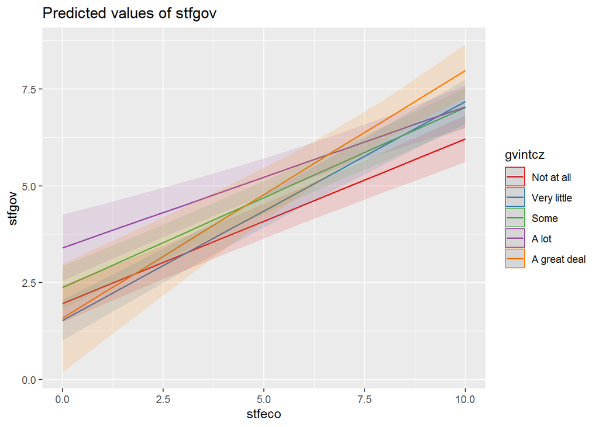

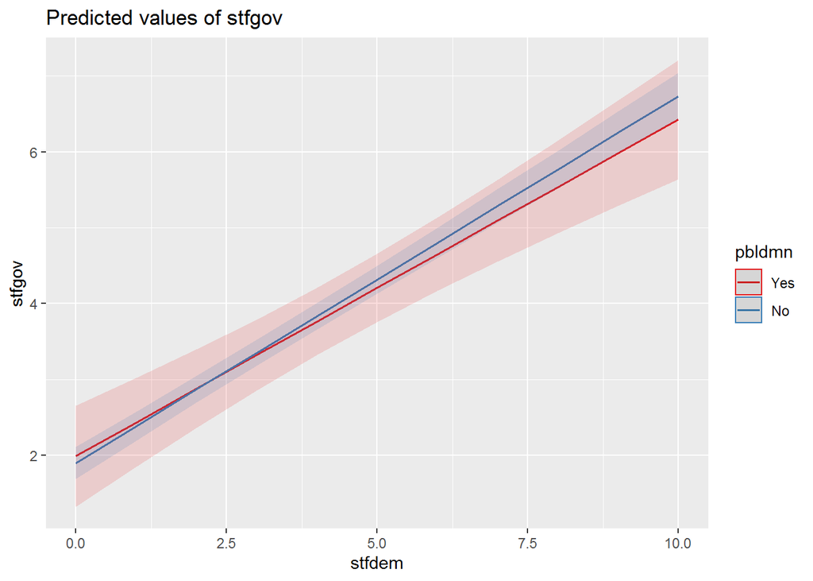

```r
plot_model(Mod6, type = "int")
```

As for the second plot. Here the moderation is quite weak, but still present. So, we may see that people who participated in meetings tend to be less satisfied with the government in addition to the democracy, than those who didn’t visit meeting last year at all.

## Sources:

1. Christensen, T., & Lægreid, P. (2005). Trust in government: The relative importance of service satisfaction, political factors, and demography. Public Performance & Management Review, 28(4), 487-511.
2. WANG, Z. (2010). Citizens’ Satisfaction with Government Performance in Six Asian-Pacific Giants. Japanese Journal of Political Science, 11 (01), 51.